# Decision Tree

```r
library(rpart)
library(rpart.plot)
library(tidyverse)
library(janitor)
titanic_set <- read_csv('data/titanic_decision_tree_data.csv')
shuffle_index <- sample(1:nrow(titanic_set))

# shuffle the data so class order isn't in order - need this for training/testing split later on
titanic_set <- titanic_set[shuffle_index, ]
```

Data Dictionary

```r
glimpse(titanic_set)
```

```
Rows: 1,309
Columns: 13
$ X1           <dbl> 1301, 589, 780, 544, 285, 531, 174, 95, 245, 1031, 914, 268, 704,…
$ passenger_id <dbl> 883, 171, 362, 126, 1176, 113, 1065, 986, 1136, 613, 496, 1159, 2…
$ pclass       <dbl> 3, 1, 2, 3, 3, 3, 3, 1, 3, 3, 3, 3, 3, 1, 3, 3, 3, 3, 1, 3, 3, 3,…
$ name         <chr> "Dahlberg, Miss. Gerda Ulrika", "Van der hoef, Mr. Wyckoff", "del…
$ sex          <chr> "female", "male", "male", "male", "female", "male", "male", "male…
$ age          <dbl> 22, 61, 29, 12, 2, 22, NA, 25, NA, NA, NA, NA, 33, 55, 19, NA, NA…
$ sib_sp       <dbl> 0, 0, 1, 1, 1, 0, 0, 0, 1, 1, 0, 0, 0, 1, 0, 0, 1, 0, 0, 0, 0, 0,…
$ parch        <dbl> 0, 0, 0, 0, 1, 0, 0, 0, 2, 0, 0, 0, 0, 0, 0, 0, 0, 0, 1, 2, 0, 0,…
$ ticket       <chr> "7552", "111240", "SC/PARIS 2167", "2651", "370129", "324669", "2…
$ fare         <dbl> 10.5167, 33.5000, 27.7208, 11.2417, 20.2125, 8.0500, 7.2292, 26.0…
$ cabin        <chr> NA, "B19", NA, NA, NA, NA, NA, NA, NA, NA, NA, NA, NA, NA, "F G73…
$ embarked     <chr> "S", "S", "C", "C", "S", "S", "C", "C", "S", "Q", "C", "S", "C", …
$ survived     <dbl> 0, 0, 0, 1, NA, 0, NA, NA, NA, 1, 0, NA, 0, NA, 0, NA, 1, 0, 1, 1…
```

```r
head(titanic_set)
```

| X1 | passenger_id | pclass | name | sex | age | sib_sp | parch | ticket | fare | cabin | embarked | survived |
| --- | --- | --- | --- | --- | --- | --- | --- | --- | --- | --- | --- | --- |
| 1301 | 883 | 3 | Dahlberg, Miss. Gerda Ulrika | female | 22 | 0 | 0 | 7552 | 10.5167 | NA | S | 0 |
| 589 | 171 | 1 | Van der hoef, Mr. Wyckoff | male | 61 | 0 | 0 | 111240 | 33.5000 | B19 | S | 0 |
| 780 | 362 | 2 | del Carlo, Mr. Sebastiano | male | 29 | 1 | 0 | SC/PARIS 2167 | 27.7208 | NA | C | 0 |
| 544 | 126 | 3 | Nicola-Yarred, Master. Elias | male | 12 | 1 | 0 | 2651 | 11.2417 | NA | C | 1 |
| 285 | 1176 | 3 | Rosblom, Miss. Salli Helena | female | 2 | 1 | 1 | 370129 | 20.2125 | NA | S | NA |
| 531 | 113 | 3 | Barton, Mr. David John | male | 22 | 0 | 0 | 324669 | 8.0500 | NA | S | 0 |

```r
summary(titanic_set)
```

```
       X1        passenger_id      pclass          name               sex
 Min.   :   1   Min.   :   1   Min.   :1.000   Length:1309        Length:1309
 1st Qu.: 328   1st Qu.: 328   1st Qu.:2.000   Class :character   Class :character
 Median : 655   Median : 655   Median :3.000   Mode  :character   Mode  :character
 Mean   : 655   Mean   : 655   Mean   :2.295
 3rd Qu.: 982   3rd Qu.: 982   3rd Qu.:3.000
 Max.   :1309   Max.   :1309   Max.   :3.000

      age            sib_sp           parch          ticket               fare
 Min.   : 0.17   Min.   :0.0000   Min.   :0.000   Length:1309        Min.   :  0.000
 1st Qu.:21.00   1st Qu.:0.0000   1st Qu.:0.000   Class :character   1st Qu.:  7.896
 Median :28.00   Median :0.0000   Median :0.000   Mode  :character   Median : 14.454
 Mean   :29.88   Mean   :0.4989   Mean   :0.385                      Mean   : 33.295
 3rd Qu.:39.00   3rd Qu.:1.0000   3rd Qu.:0.000                      3rd Qu.: 31.275
 Max.   :80.00   Max.   :8.0000   Max.   :9.000                      Max.   :512.329
 NA's   :263                                                         NA's   :1
    cabin             embarked            survived
 Length:1309        Length:1309        Min.   :0.0000
 Class :character   Class :character   1st Qu.:0.0000
 Mode  :character   Mode  :character   Median :0.0000
                                       Mean   :0.3838
                                       3rd Qu.:1.0000
                                       Max.   :1.0000
                                       NA's   :418
```

1.1 Question 1

Cleaning up the data is always the first step. Do the following:

Take only observations which have a survived flag (i.e. that aren’t missing) Turn your important variables into factors (sex, survived, pclass, embarkation) Create an age_status variable which groups individuals under (and including) 16 years of age into a category called “child” category and those over 16 into a category called “adult”. Drop the NA Drop any variables you don’t need (X1, passenger_id, name, ticket, far, cabin) If you need help doing this, the code is below, but please try it yourself first so you can learn!

```r
titanic_clean <- titanic_set %>%
  #filter by those you survived or not (removing na's)
  filter(survived %in% c(0,1)) %>%
# Convert to factor level
    mutate(sex = as.factor(sex),
           age_status = as.factor(if_else(age <= 16, "child", "adult")),
         class = factor(pclass, levels = c(3,2,1), labels = c("Lower", "Middle", "Upper")),
           survived_flag = factor(survived, levels = c(0,1), labels = c("No", "Yes")),
           port_embarkation = as.factor(embarked)) %>%
  select(sex, age_status, class, port_embarkation, sib_sp, parch, survived_flag) %>%
  #omit na's
  na.omit()
```

```r
summary(titanic_clean)
```

```
     sex      age_status     class     port_embarkation     sib_sp          parch
 female:259   adult:612   Lower :355   C:130            Min.   :0.000   Min.   :0.0000
 male  :453   child:100   Middle:173   Q: 28            1st Qu.:0.000   1st Qu.:0.0000
                          Upper :184   S:554            Median :0.000   Median :0.0000
                                                        Mean   :0.514   Mean   :0.4326
                                                        3rd Qu.:1.000   3rd Qu.:1.0000
                                                        Max.   :5.000   Max.   :6.0000
 survived_flag
 No :424
 Yes:288
```

1.2 Question 2

Have a look at your data and create some plots to ensure you know what you’re working with before you begin. Write a summary of what you have found in your plots. Which variables do you think might be useful to predict whether or not people are going to die? Knowing this before you start is the best way to have a sanity check that your model is doing a good job.

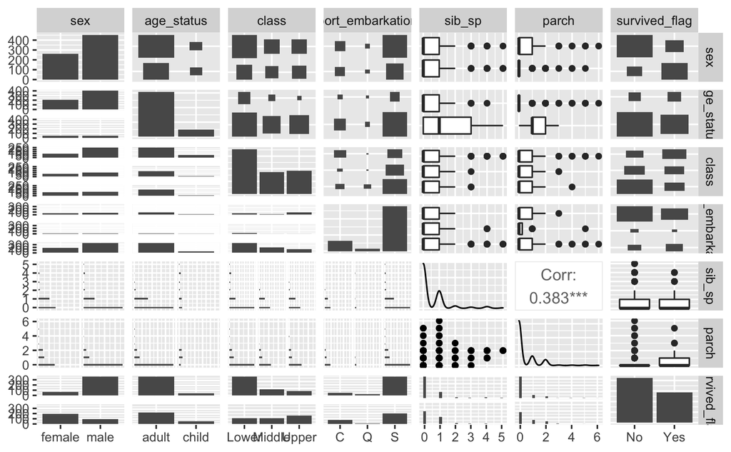

```r
library(GGally)
ggpairs(titanic_clean)
```

Sex, age_status & port embarkation against survived_flag show separation. Sib_sp does not look like it would be a significant predictor for survived_flag, not does parch.

1.3 Question 3

Now you can start to build your model. Create your testing and training set using an appropriate split. Check you have balanced sets. Write down why you chose the split you did and produce output tables to show whether or not it is balanced. [Extra - if you want to force balanced testing and training sets, have a look at the stratified() function in package splitstackshape (you can specify multiple variables to stratify on by passing a vector of variable names to the group argument, and get back testing and training sets with argument bothSets = TRUE)]

```r
# get how many rows we have in total to work out the percentage
n_data <- nrow(titanic_clean)

# create a test sample index
test_index <- sample(1:n_data, size = n_data*0.2)

# create test set
titanic_test  <- slice(titanic_clean, test_index)

# create training set
titanic_train <- slice(titanic_clean, -test_index)
```

I have chosen a split of 80% training data and 20% test data as there is not a lot of data (only 712 observations). If there was a much more substantial quantity of data, I would use a 90/10 split perhaps.

```r
titanic_test %>%
tabyl(survived_flag)
```

```
 survived_flag  n   percent
            No 90 0.6338028
           Yes 52 0.3661972
```

```r
titanic_train %>%
tabyl(survived_flag)
```

```
 survived_flag   n   percent
            No 334 0.5859649
           Yes 236 0.4140351
```

The test data agrees with the training data in that the proportion of passengers who did not survive the titanic sinking are higher than those who did. However, the figures do differ between test and training output.

1.4 Question 4

Create your decision tree to try and predict survival probability using an appropriate method, and create a decision tree plot.

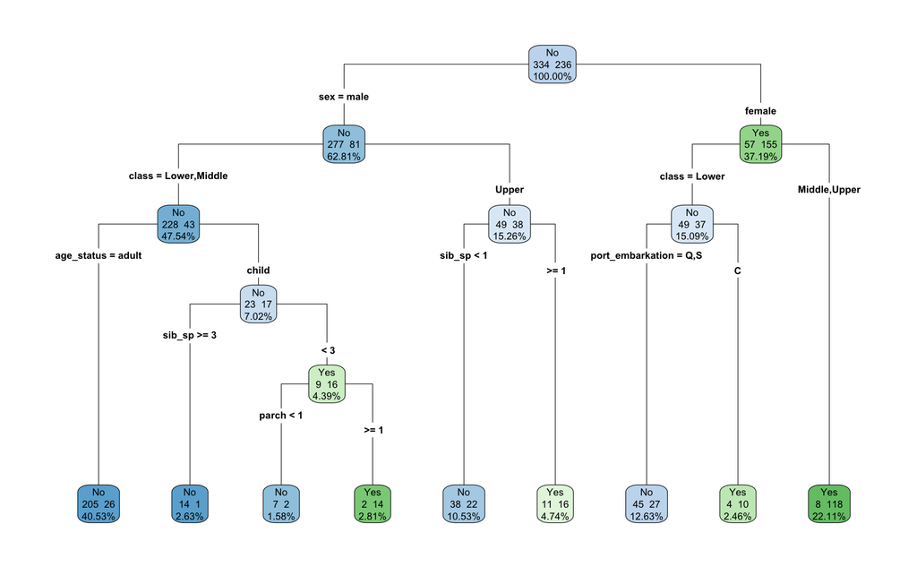

```r
titanic_fit <- rpart(
  formula = survived_flag ~ .,
  data = titanic_train,
  method = 'class'
)

rpart.plot(titanic_fit,
           yesno = 2,
           fallen.leaves = TRUE,
           faclen = 6,
           digits = 4,
           type = 4,
           extra = 101)
```

1.5 Question 5

Write down what this tells you, in detail. What variables are important? What does each node tell you? Who has the highest chance of surviving? Who has the lowest? Provide as much detail as you can.

1.6 Question 6

Test and add your predictions to your data. Create a confusion matrix. Write down in detail what this tells you for this specific dataset.

```r
library(modelr)
# add the predictions
titanic_test_pred <- titanic_test %>%
  add_predictions(titanic_fit, type = 'class')

# look at the variables
titanic_test_pred
```

| sex | age_status | class | port_embarkation | sib_sp | parch | survived_flag | pred |
| --- | --- | --- | --- | --- | --- | --- | --- |
| female | child | Lower | C | 1 | 0 | No | Yes |
| male | adult | Middle | S | 1 | 0 | No | No |
| male | adult | Middle | S | 0 | 0 | No | No |
| female | adult | Upper | S | 1 | 1 | Yes | Yes |
| female | adult | Upper | S | 0 | 0 | Yes | Yes |
| male | adult | Lower | S | 0 | 0 | No | No |
| male | adult | Lower | S | 1 | 0 | No | No |
| male | adult | Middle | S | 1 | 1 | No | No |
| male | adult | Lower | S | 0 | 0 | No | No |
| male | adult | Lower | S | 0 | 0 | No | No |

[output cut: 132 more lines]

```r
library(yardstick)
```

Generating a confusion matrix

```r
conf_mat <- titanic_test_pred %>%
              conf_mat(truth = survived_flag, estimate = pred)

conf_mat
```

```
          Truth
Prediction No Yes
       No  80  19
       Yes 10  33
```

The confusion matrix shows that the ‘correct’ predictions, i.e. true negatives and true positives are on the top left to bottom right diagonal. The ‘incorrect’ predictions, i.e. false negatives and false positives are on the bottom left to top right diagonal. A perfect classifier would have zeroes on this diagonal.

In this example:-

```r
accuracy <- titanic_test_pred %>%
 accuracy(truth = survived_flag, estimate = pred)

accuracy
```

| .metric | .estimator | .estimate |
| --- | --- | --- |
| accuracy | binary | 0.7957746 |

```r
titanic_test_pred %>%
  sensitivity(truth = survived_flag, estimate = pred)
```

| .metric | .estimator | .estimate |
| --- | --- | --- |
| sens | binary | 0.8888889 |

```r
titanic_test_pred %>%
  specificity(truth = survived_flag, estimate = pred)
```

| .metric | .estimator | .estimate |
| --- | --- | --- |
| spec | binary | 0.6346154 |

```r
library(caret)
confusionMatrix(titanic_test_pred$pred, titanic_test_pred$survived_flag)
```

[output not shown]